# Modeling workflow: NLA N2O survey data

Roy Martin, Jake Beaulieu, Michael McManus 2025-03-17

# 1 Introduction

This supplement documents the modeling workflow used for estimating dissolved and equilibrium N2O gas concentrations and saturation ratios for freshwater lakes (natural and man-made) across the continental United States (CONUS). Data for the estimates came from the 2017 Nation Lakes Assessment (NLA) survey, which aimed to provide representative samples for describing environmental conditions across CONUS lakes during the summer index period of 2017 (U.S. EPA 2015). The population of interest (POI) for this study was defined as all lakes and reservoirs in the CONUS that were (1) larger than 1 hectare, (2) with at least 0.1 hectares of open water, (3) at least 1 meter deep, and (4) with a residence time of less than 1 week. The 2017 NLA sampling frame consisted of 465,897 lakes delineated from georeferenced data documented in the National Hydrography Dataset (NHD). The samples were drawn according to a spatially balanced, stratified, and unequal probability design. Sampling was stratified among categories of lake size (surface area in hectares), WSA9 ecoregion, and US state (excluding AK and HI). The probability of selection was greater for larger lakes relative to smaller ones in order to sufficiently represent larger lakes in a sample of practical size. Small lakes vastly outnumber large ones in the POI.

The POI was defined in this study explicitly by the NLA 2017 sampling frame ((U.S. EPA 2015)). Therefore, the effective and stated POI may depart in important ways that would be difficult to confirm in practice. For example, it would be impractical to visit all lakes in the sampling frame to determine which contained less than 0.1 ha of open water or were less than 1 meter deep. These conditions were evaluated in the field for sites that were sampled. If a field crew arrived at a site that did not meet the conditions for inclusion, another site could be chosen from an oversample frame. In effect, the size of the stated POI is likely smaller than the 465,897 lakes described in the sampling frame and, therefore, the possibility of some remaining biases in these estimates should be considered, if only to emphasize that there remains uncertainty in the population-level estimates beyond what was estimated from modeling. Though it may be practically impossible to determine the precise magnitude or direction in which any particular estimate could be biased, it is clear that estimates could vary systematically given any substantial mismatches between the POI and the sampling frame.

When making inferences to a POI from a sample, estimates should be adjusted to address potential biases resulting from known differences between the POI and sample. For this study, lakes in the POI were missing from the sample not completely at random, but systematically and according to the probability assigned by the survey design. This type of “missingness” is not ignorable for making inferences from a sample, but may be considered ignorable if the inferences are adjusted such that they are conditional on the survey design (Gelman et al. 2014, Ch. 8; Gelman, Hill, and Vehtari 2020 Ch. 17). A straightforward approach to adjustment is to simply include the design variables as predictors in a regression model for the surveyed responses of interest (Gelman, Hill, and Vehtari 2020, Ch. 17). Then, in a second step referred to as “poststratification” (Gelman, Hill, and Vehtari 2020, Ch. 17), the model parameter estimates can be used to make population-level estimates by summarizing over the known distribution of the design variables in the POI or sub-populations therein. Multilevel regression models are often preferred in this approach, which is why it is often referred to as multilevel regression with poststratification, or MRP (Park, Gelman, and Bafumi 2004; Gelman and Little 1997; Gelman, Hill, and Vehtari 2020, Ch. 17; Kennedy and Gelman 2021). Multilevel regression models are recommended because they naturally provide regularized estimates along the design groupings, which can improve out-of-sample inferences (Gelman and Little 1997). Likewise, estimates for group levels that may be missing from the sample (e.g., an unsampled U.S. state), but are part of the POI, are straightforward using the multilevel approach (Gelman, Hill, and Vehtari 2020 Ch. 17; McElreath 2020). For a worked and narrated example using this approach, see a recent paper by Kennedy and Gelman (Kennedy and Gelman 2021). For an example in the context of national surveys of environmental resources, see a recent paper from Zachmann and others (Zachmann et al. 2022).

In this study, we used the 2017 NLA survey data and an adjustment approach similar to MRP to provide population-level estimates for (1) dissolved and equilibrium N2O concentrations; (2) the N2O saturation ratio (i.e., dissolved N2O/equilibrium N2O); and (3) the proportion of under-saturated water bodies (i.e., saturation ratio < 1). The resulting estimates were later combined with lake-level attributes (e.g., surface area) to provide estimates of N2O emission rates and flux. A number of Bayesian multilevel regression models were fit to the survey data and predictions from those models were checked against both the data used in their fitting as well as a subset of held-out data from re-visited sites. Because dissolved and equilibrium N2O were each observed on the same sample units (a single site within each waterbody), our regression models were constructed to estimate their joint probability distribution. The multivariate response allowed for conditional dependencies between dissolved and equilibrium N2O due to, for example, physiography. Although predictions from separate models for each N2O response may have provided comparable estimates, a joint model was expected to better capture uncertainty and potentially improve out-of-sample predictions, should the data be conditionally correlated (Warton et al. 2015; Poggiato et al. 2021). The saturation ratio (saturation = dissolved N2O/equilibrium N2O) was estimated as a derived quantity calculated from the joint posterior predictive distribution of the two N2O variables.

Our initial regression models were focused on conditioning the N2O data on the survey design factors only, which included multilevel groupings of the sampled lakes according to WSA9 ecoregion, states within ecoregions, and size classes within states. Although these initial models performed well at replicating the observed group-level means, further model checking indicated that they did a relatively poor job of replicating some tail properties, such as the long right tail of the observed dissolved N2O data. As a result of this misfit, the predictive distribution for the saturation ratio was also consistently biased low relative to the observed data. In subsequent models, we found that including an NO3 covariate was particularly helpful for better replicating these extreme values. The addition of predictors for surface temperature and lake surface area, along with interaction terms for these predictors with NO3, also lead to apparent improvements. Likewise, the inclusion of surface temperature and elevation covariates in the equilibrium N2O response resulted in improvements over the initial models, as did added flexibility in the distributional terms (heterogeneous errors) for both dissolved and equilibrium N2O.

A number of additional, potentially relevant covariates were evaluated in exploratory analyses and models, but are not covered in this document. These variables are, however, available to the public should the reader wish to further explore their utility. These measures, which were taken at the time of N2O sampling or constructed from those measures, included chlorophyll a concentration, dissolved oxygen (DO) content at the surface, and a buoyancy metric. Some of these variables are also covered in the data munging document at: https://github.com/USEPA/DissolvedGasNla/blob/master/scripts/dgIndicatorAnalysis.html. An exploratory analysis using classification trees in that document suggested that NO3 as well as both mean depth and chlorophyll a concentration were associated with dissolved N2O concentration. The decision to not include these variables in the final model was based on several issues. First, our primary goal was to make population-level estimates for N2O while considering the survey design structure. As a result, we were less concerned with exploring the relative contributions of environmental correlates to N2O variation. However, our initial models excluding all covariates proved to result in relatively poor fits to important aspects of the observed data. In an attempt to improving the fit, the NO3 covariate was then included due to the relatively large effects implied in exploratory analyses (see “Sample Data Exploration” to follow). Conversely, our evaluations of exploratory plots and models with chlorophyll a, surface DO, and the BF covariates did not result in similarly substantial improvements. Second, these other covariates were only available in the sample and, therefore, were not fully observed in the POI. As such, using them to make population-level predictions would have come with additional complexity (discussed below) that didn’t appear to be reciprocated by critical improvements in model fit. Finally, several observations were missing from the sample for these covariates. To include them in our model would have required sub-models for the missing data, resulting in added complexity and computational burden that, again, did not appear to be worth the added complexity and computational burden. Hence, the progression of models presented in this supplement was intended to efficiently convey the improvements in fit following the addition of key covariates and parameterizations that ultimately comprised the final model.

The first regression model we fit was constructed to estimate the joint distribution of log-transformed dissolved and equilibrium N2O conditional only on the the survey design factors, such that:

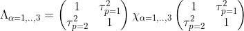

The multivariate mean was defined by a vector of location parameters, , for each response, . As noted above, each location parameter was also defined according to a linear combination of parameters indexed to each response and observation . This linear combination included a fixed global intercept, , conditioned on the data, and three latent group-level effects matrices, . The effects in each of these matrices were also drawn from MVN probability distributions centered on zero in -dimensional space. The spread of the effects around zero were determined by a corresponding variance-covariance matrix, . The standard deviation parameters, , of those matrices were conditioned on the data and captured group-level standard deviations that controlled the spread of the group-level effects for each response. The parameter contained the group-level residual correlation matrix, wherein denotes the group-level residual correlations (i.e., between responses).

The explicit indexing in the notation above conveys the relationship between the parameters and each observation, , and emphasizes the nested structure of the observations within the group effects. Specifically, each observation, , was nested in a lake size category, , which was nested in a state, , and ecoregion, . The group-level effects in , therefore, accounted for ecoregion-level deviations from the global mean; accounted for state-level group effects nested in ecoregions; and accounted for lake size category effects within states and ecoregions.

Finally, the observation-level covariance term, , comprised of the observation-level standard deviations, , for each response, and or the observation-level residual correlation matrix, wherein captured residual correlation between responses.

In the package, there is additional functionality and formula syntax for multivariate responses, which allows for the varying intercepts of the separate linear predictors in a multivariate model to be correlated across responses, e.g.,:

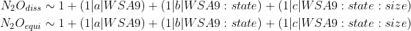

The above formula syntax indicates that the linear predictor for both N2O responses have the same group-level varying effects terms, and that the effects associated with each of those terms can be correlated across responses. The relevant sections of code that are helpful for describing the first model above using syntax are below:

```r
# Assign separate linear predictors for the dissolved and equilibrium N2O responses
bf_n2o <- bf(log(n2o) ~ 1 +
               (1 | a | WSA9) +
               (1 | b | WSA9:state) +
               (1 | c | WSA9:state:size_cat),
             family = gaussian())

bf_n2oeq <- bf(log(n2o_eq) ~ 1 +
               (1 | a | WSA9) +
               (1 | b | WSA9:state) +
               (1 | c | WSA9:state:size_cat),
             family = gaussian())

# Set priors for parameters
priors <- c(
  prior(normal(2, 1), class = "Intercept", resp = "logn2o"), # alpha_0
  prior(exponential(2), class = "sd", resp = "logn2o"), # sd alpha_1..3
  prior(exponential(2), class = "sigma", resp = "logn2o"), # observation level sd
  prior(normal(2, 1), class = "Intercept", resp = "logn2oeq"),
  prior(exponential(2), class = "sd", resp = "logn2oeq"),
  prior(exponential(2), class = "sigma", resp = "logn2oeq"),
  prior(lkj(2), class = "rescor"), # observation level residual correlation
  prior(lkj(2), class = "cor") # correlation for group effects
  )

# Fit the multivariate model
n2o_mod1 <- brm(bf_n2o + bf_n2oeq + set_rescor(rescor = TRUE), ...)
```

The first two objects assigned in the above code example are the linear predictors assigned to the dissolved and equilibrium N2O responses. The second object is a list of priors as defined above. The third object results from the `brm()` call to fit the model. In this syntax, the two linear predictor objects are “added” along with the `set_rescor(rescor = TRUE)` option, which defines whether the residual correlation is to be modeled (TRUE) or not (FALSE). Note that, with `set_rescor(rescor = FALSE)` and without the correlated group effects (i.e., ‘a’, ‘b’, ‘c’), would effectively treat the two responses as entirely independent in fitting.

For the remainder of this document, only this simplified syntax is presented to describe the model structure. For more information on functionality and syntax with multivariate response models, see the package vignette: https://cran.r-project.org/web/packages/brms/vignettes/brms_multivariate.html.

The relevant code for the final model used for inference and described in the main paper is below:

```r
# Assign separate linear predictors for each response: N2O, N2o-eq, Surface temp, and NO3 level.

# N2O
bf_n2o <- bf(n2o ~ mo(no3_cat) +
               log_area +
               surftemp +
               mo(no3_cat):log_area +
               mo(no3_cat):surftemp +
               (mo(no3_cat) | a | WSA9) +
               (mo(no3_cat) | b | WSA9:state) +
               (1 | c | WSA9:state:size_cat),
             shape ~ log_area +
               mo(no3_cat) +
               (1 | WSA9) +
               (1 | WSA9:state) +
               (1 | WSA9:state:size_cat),
             family = Gamma(link = "log"))

# Equilibrium N2O
bf_n2oeq <- bf(n2o_eq ~ surftemp +
                 log_elev +
                 surftemp:log_elev +
                 (1 | a | WSA9) +
                 (1 | b | WSA9:state) +
                 (1 | c | WSA9:state:size_cat),
             shape ~ surftemp +
               log_elev +
               (1 | WSA9) +
               (1 | WSA9:state) +
               (1 | WSA9:state:size_cat),
             family = Gamma(link = "log"))

# Surface temperature
bf_temp <- bf(surftemp ~ lat +
                s(log_elev) +
                s(jdate) +
                (1 | a | WSA9) +
                (1 | b | WSA9:state) +
                (1 | c | WSA9:state:size_cat),
              shape ~ lat,
              family = Gamma(link = "log"))

# NO3 level
bf_no3 <- bf(no3_cat ~ surftemp +
               log_area +
               (1 | a | WSA9) +
               (1 | b | WSA9:state) +
               (1 | c | WSA9:state:size_cat),
             family = cumulative(link = "logit", threshold="flexible"))

# Assign priors
priors <- c( # N2O
  prior(normal(2, 1), class = "Intercept", resp = "n2o"),
  prior(normal(0, 1), class = "b", resp = "n2o"),
  prior(exponential(2), class = "sd", resp = "n2o"),
  prior(normal(5, 4), class = "Intercept", dpar = "shape", resp = "n2o"),
  prior(normal(0, 1), class = "b", dpar = "shape", resp = "n2o"),
  prior(exponential(2), class = "sd", dpar = "shape", resp = "n2o"),

  # Equil N2O
  prior(normal(2, 1), class = "Intercept", resp = "n2oeq"),
  prior(normal(0, 1), class = "b", resp = "n2oeq"),
  prior(exponential(2), class = "sd", resp = "n2oeq"),
  prior(normal(5, 4), class = "Intercept", dpar = "shape", resp = "n2oeq"),
  prior(normal(0, 1), class = "b", dpar = "shape", resp = "n2oeq"),
  prior(exponential(2), class = "sd", dpar = "shape", resp = "n2oeq"),

  # Surface temp
  prior(normal(3, 1), class = "Intercept", resp = "surftemp"),
  prior(normal(0, 1), class = "b", resp = "surftemp"),
  prior(exponential(0.5), class = "sds", resp = "surftemp"),
  prior(exponential(2), class = "sd", resp = "surftemp"),
  prior(normal(5, 4), class = "Intercept", dpar = "shape", resp = "surftemp"),
  prior(normal(0, 1), class = "b", dpar = "shape", resp = "surftemp"),

  # NO3
  prior(normal(0, 3), class = "Intercept", resp = "no3cat"),
  prior(normal(0, 1), class = "b", resp = "no3cat"),
  prior(exponential(1), class = "sd", resp = "no3cat"),

  prior(lkj(2), class = "cor")
  )

# Fit the multivariate model
n2o_mod6 <- brm(bf_n2o + bf_n2oeq + bf_temp + bf_no3 + set_rescor(rescor = FALSE), ...)
```

In this final model, the dissolved and equilibrium N2O responses were each modeled with Gamma distributed errors. The Gamma error structure appeared to result in slightly better performance in the predictive checks compared to the Gaussian errors. This was primarily apparent in the saturation ratio checks, which may have been more sensitive to model performance in the tails of the N2O responses. Others have indicated that the Gamma error distribution can work well for modeling dissolved N2O data (Webb et al. 2019). The linear predictor for dissolved N2O included the survey design effects along with covariate terms for lake area (ha), NO3 level, and surface water temperature. To accomodate heterogeneous errors, the shape parameter of the Gamma distribution was modeled as a function of NO3 level, lake area, and the survey design factors. The equilibrium N2O response was modeled as a function of the survey design factors, lake elevation, and lake surface temperature. The shape parameter was, again, allowed to vary conditional on the survey factors, surface temperature, and elevation.

The sub-model for the surface temperature response also assumed a Gamma distributed error distribution and covariates included the survey design variables, latitude, elevation, and Julian date. The shape parameter was also modeled as a function of latitude to address increasing temperature variance along the latitudinal gradient.

The NO3 sub-model was a cumulative logit model and the linear predictor included all of the survey factors as well as surface temperature and lake area.

Note that there was no observation-level residual correlation term for this final model, since the residuals are undefined for the Gamma and cumulative logit models. Dropping the observation-level residual correlation term was deemed a reasonable compromise that enabled the inclusion of NO3 as a covariate on dissolved N2O. The random intercepts, however, still allowed for potential correlations between the four responses at the group levels. As mentioned previously, including covariates that were not available in the full POI necessitated some additional steps in the poststratification process. To make population-level inferences from a model with covariates, those covariates need to be (1) fully observed across the POI or (2) their “missingness” needs to be addressed with modeling. For the lake area and elevation covariates, for example, data was available for the entire POI from previously compiled geospatial databases. However, neither surface temperature or NO3 were observed for lakes outside of the sample. That is, they were partially observed with respect to the POI. Therefore, the final multivariate model, coded above included these as additional responses, with each also being conditioned on the survey design structure and the fully observed covariates. The dependence structure among the fully and partially observed variables in this model could be described such that:

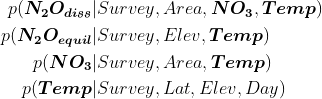

Variables in bold text above were partially observed with respect to the POI (i.e., observed only in the sample), whereas variables not in bold were considered fully observed. The partially observed variables, being dissolved and equilibrium N2O, NO3, and surface temperature, were each modeled conditional on the survey design variables and other partially and/or fully observed covariates. This piece-wise approach then required a more complex set of post-processing steps compared to a typical MRP analysis. In order to propagate uncertainty through to the population-level inferences, the fitted model was first used to predict surface temperature in the target population, since it depended only on the fully observed covariates. That predictive distribution was then used alongside the relevant fully observed covariates to predict NO3 in the target population. Finally, these predictive distributions for temperature and NO3 were used to predict the N2O responses. These steps were carried out in the “Predict to population” section below. This approach is similar to MRP approaches with “non-census” variables (Kennedy and Gelman 2015). It could also be described as a form of Bayesian structural equation model (Merkle et al. 2021; Merkle and Rosseel 2018).

Finally, because N2O flux was to be later estimated as a function of lake-level measures (*e.g.*, surface area), predictions for N2O were made to each of the 465,897 individual lakes in the POI. For population level estimates of dissolved N2O, equilibrium N2O, and N2O saturation, the lake-level predictions were summarized across the relevant units (*e.g.*, CONUS, ecoregion). Predictions were assumed relevant for average conditions during the biological index period of 2017.

All of the models were constructed and assessed within in `R` (R Core Team 2021) using the `brms` package (Bürkner 2017) as an interface to Stan, a software package for fitting fully Bayesian models via Hamiltonian Monte Carlo (HMC, Stan Development Team 2018b, 2018c, 2018a). More specific details on the model structures and fits is provided in the “Model fitting” section below.

# 2 Data

As explained in the data munging document document (https://github.com/USEPA/DissolvedGasNla/blob/master/scripts/dgIndicatorAnalysis.html), duplicate dissolved gas samples were collected at a depth of ~0.1m at designated index sites distributed across 1091 lakes nationwide, of which 95 were sampled twice as repeat visits. This subset of revisit sites was used as a test set for assessing model fit and out-of-sample performance.

Water samples were analyzed via gas chromotography and concentrations were recorded to the nearest 0.001 nmol/L. As part of the survey design, each gas observation was indexed to an individual lake selected with unequal probability from 5 different lake size categories, , according to surface area (ha), and from within a state, , situated within an aggregated, WSA9 or Omernik ecoregion, . All WSA9 ecoregions were represented, including the Xeric (XER), Western Mountain (WMT), Northern Plains (NPL), Southern Plains (SPL), Temperate Plains (TPL), Coastal Plains (CPL), Upper Midwest (UMW), Northern Appalachian (NAP), and Southern Appalachian (SAP) regions. Gas data from the first and second (follow-up) visits were separated, with *vs.* observations each. In addition to the design variables, a number of potentially useful covariates were also indexed to the gas observations, including measures of NO3, surface water temperature, elevation, chlorophyll a content, dissolved oxygen content, and waterbody size (hectares). These gas data and covariates were previously described and munged at: https://github.com/USEPA/DissolvedGasNla/blob/master/scripts/dataMunge.html.

## 2.1 Import

That originally munged gas dataset is imported below.

```r
load("./inputData/dg.RData")
```

A new data frame for modeling was constructed from the original file, including only the variables of interest: (1) the N2O gas observations; (2) the survey design variables indexed to those observations; and (3) measures and metrics considered potentially useful as covariates for improving the fit and/or practical interpretation of the model. The modeling data frame below excluded the second-visit observations, which would later be used for model checking. Some variables from the imported data were renamed for convenience. In addition, the NO3 covariate was rounded according to the documented measurement precision and an alternative version was created by log-transforming and re-coding the variable as an ordered factor with five levels. The left-most cut point separated observations below the detection limit from the completely observed samples. The remaining cut points were drawn at equal distances in the positive direction along the log scale.

```r
dg %>%
  filter(sample.source == "DG") %>%
  nrow() # number of dissolved gas observations before filtering out probability sites and second visits
```

```
## [1] 1185
```

```r
df_model <- dg %>%
  filter(sample.source == "DG", # dissolved gas info
         sitetype == "PROB") %>% # probability samples only
  filter(visit.no == 1) %>% # first-visit sites only
  mutate(n2o = round(dissolved.n2o.nmol, 2),
         n2o_eq = round(sat.n2o.nmol, 2),
         n2o_sat = n2o.sat.ratio,
         n2o_em = e.n2o.nmol.d,
         n2o_flux = f.n2o.m.d,
         WSA9 = factor(ag.eco9),
         state = factor(state.abb[match(state.nm, state.name)]),
         area_ha = area.ha,
         log_area = log(area_ha),
         chla = chla.result,
         log_chla = log(chla),
         elev = elevation,
         log_elev = log(elev + 1),
         do_surf = o2.surf,
         log_do = log(do_surf),
         bf_max = max.bf,
         sqrt_bf = sqrt(bf_max),
         size_cat = recode(area.cat6, # simpler naming conventions for the size categories
                           "(1,4]" = "min_4" ,
                           "(10,20]" = "10_20",
                           "(20,50]" = "20_50",
                           "(4,10]" = "4_10",
                           ">50" = "50_max")) %>%
  mutate(size_cat = factor(size_cat,
                           levels = c("min_4", "4_10", "10_20", "20_50", "50_max"),
                           ordered = TRUE)) %>%
  mutate(no3 = ifelse(nitrate.n.result <= 0.0005, 0.0005, round(nitrate.n.result, 4))) %>%# 1/2 mdl 0.01
  mutate(no3_cat = cut(log(no3), # convert no3 to ordered factor with 5 levels
                       breaks = c(-Inf, -7.5, -5.5, -3.5, -1.5, Inf),
                       labels =seq(1, 5, 1))) %>%
  mutate(no3_cat = factor(no3_cat,
                          levels = seq(1, 5, 1),
                          ordered = TRUE)) %>%
  mutate(date = as.Date(date.col)) %>%
  mutate(jdate = as.numeric(format(date, "%j"))) %>%
  mutate(lat = map.lat.dd,
         lon = map.lon.dd) %>% # longitude
  mutate(surftemp = surftemp,
         log_surftemp = log(surftemp)) %>%
  select(WSA9,
         state,
         size_cat,
         site.id,
         lat,
         lon,
         date,
         jdate,
         surftemp,
         log_surftemp,
         area_ha,
         log_area,
         elev,
         log_elev,
         chla,
         log_chla,
         do_surf,
         log_do,
         bf_max,
         sqrt_bf,
         n2o,
         n2o_eq,
         no3,
         no3_cat
         )

save(df_model, file = "/modelFiles/df_model.rda")
```

A preview of the 984 probability samples to be used in modeling:

```r
df_model %>%
  head()
```

```
## # A tibble: 6 × 24
##   WSA9  state size_cat site.id          lat   lon date       jdate surftemp
##   <fct> <fct> <ord>    <chr>          <dbl> <dbl> <date>     <dbl>    <dbl>
## 1 SAP   AL    50_max   NLA17_AL-10001  33.3 -87.4 2017-07-10   191     23.9
## 2 SAP   AL    50_max   NLA17_AL-10002  33.7 -86.2 2017-08-14   226     28.1
## 3 CPL   AL    50_max   NLA17_AL-10003  32.5 -87.8 2017-07-12   193     27.2
## 4 CPL   AL    20_50    NLA17_AL-10004  31.6 -88.4 2017-07-14   195     29
## 5 CPL   AL    4_10     NLA17_AL-10005  33.4 -88.2 2017-07-11   192     28
## 6 CPL   AL    10_20    NLA17_AL-10008  32.2 -87.8 2017-07-13   194     29
## # ℹ 15 more variables: log_surftemp <dbl>, area_ha <dbl>, log_area <dbl>,
## #   elev <dbl>, log_elev <dbl>, chla <dbl>, log_chla <dbl>, do_surf <dbl>,
## #   log_do <dbl>, bf_max <dbl>, sqrt_bf <dbl>, n2o <dbl>, n2o_eq <dbl>,
## #   no3 <dbl>, no3_cat <ord>
```

A second data frame, including only the second visit observations was constructed below. These data were later used as a “test set” to assess the out-of-sample performance of the model developed on the first-visit or “training set”.

```r
df_test <- dg %>%
  filter(sample.source == "DG", # dissolved gas info
         sitetype == "PROB") %>% # probability samples only
  filter(visit.no == 2) %>% # second-visit sites only
  mutate(n2o = round(dissolved.n2o.nmol, 2),
         n2o_eq = round(sat.n2o.nmol, 2),
         n2o_sat = n2o.sat.ratio,
         n2o_em = e.n2o.nmol.d,
         n2o_flux = f.n2o.m.d,
         WSA9 = factor(ag.eco9),
         state = factor(state.abb[match(state.nm, state.name)]),
         area_ha = area.ha,
         log_area = log(area_ha),
         chla = chla.result,
         log_chla = log(chla),
         elev = elevation,
         log_elev = log(elev + 1),
         do_surf = o2.surf,
         log_do = log(do_surf),
         bf_max = max.bf,
         sqrt_bf = sqrt(bf_max),
         size_cat = recode(area.cat6, # simpler naming conventions for the size categories
                           "(1,4]" = "min_4" ,
                           "(10,20]" = "10_20",
                           "(20,50]" = "20_50",
                           "(4,10]" = "4_10",
                           ">50" = "50_max")) %>%
  mutate(size_cat = factor(size_cat,
                           levels = c("min_4", "4_10", "10_20", "20_50", "50_max"),
                           ordered = TRUE)) %>%
  mutate(no3 = ifelse(nitrate.n.result <= 0.0005, 0.0005, round(nitrate.n.result, 4))) %>%# 1/2 mdl 0.01
  mutate(no3_cat = cut(log(no3), # convert no3 to ordered factor with 5 levels
                       breaks = c(-Inf, -7.5, -5.5, -3.5, -1.5, Inf),
                       labels =seq(1, 5, 1))) %>%
  mutate(no3_cat = factor(no3_cat,
                          levels = seq(1, 5, 1),
                          ordered = TRUE)) %>%
  mutate(date = as.Date(date.col)) %>%
  mutate(jdate = as.numeric(format(date, "%j"))) %>%
  mutate(lat = map.lat.dd,
         lon = map.lon.dd) %>% # longitude
  mutate(surftemp = surftemp,
         log_surftemp = log(surftemp)) %>%
  select(WSA9,
         state,
         size_cat,
         site.id,
         lat,
         lon,
         date,
         jdate,
         surftemp,
         log_surftemp,
         area_ha,
         log_area,
         elev,
         log_elev,
         chla,
         log_chla,
         do_surf,
         log_do,
         bf_max,
         sqrt_bf,
         n2o,
         n2o_eq,
         no3,
         no3_cat
         )

save(df_test, file = "modelFiles/df_test.rda")
```

A preview of the re-visit data with 95 observations:

```r
df_test %>%
  head()
```

```
## # A tibble: 6 × 24
##   WSA9  state size_cat site.id          lat    lon date       jdate surftemp
##   <fct> <fct> <ord>    <chr>          <dbl>  <dbl> <date>     <dbl>    <dbl>
## 1 SAP   AL    50_max   NLA17_AL-10001  33.3  -87.4 2017-08-14   226     28.2
## 2 CPL   AL    20_50    NLA17_AL-10004  31.6  -88.4 2017-08-16   228     29
## 3 CPL   AR    50_max   NLA17_AR-10001  34.5  -92.3 2017-07-20   201     28.8
## 4 CPL   AR    4_10     NLA17_AR-10003  33.1  -92.7 2017-09-06   249     24.1
## 5 XER   AZ    50_max   NLA17_AZ-10001  33.6 -112.  2017-08-30   242     28
## 6 WMT   AZ    20_50    NLA17_AZ-10006  33.8 -109.  2017-08-08   220     20.2
## # ℹ 15 more variables: log_surftemp <dbl>, area_ha <dbl>, log_area <dbl>,
## #   elev <dbl>, log_elev <dbl>, chla <dbl>, log_chla <dbl>, do_surf <dbl>,
## #   log_do <dbl>, bf_max <dbl>, sqrt_bf <dbl>, n2o <dbl>, n2o_eq <dbl>,
## #   no3 <dbl>, no3_cat <ord>
```

## 2.2 Target population

Below, the 2017 NLA sampling frame was imported and filtered to include only lakes in the assumed POI. The resulting target population included a total of 465,897 waterbodies.

```r
df_pop <- read.csv(archive::archive_read("inputData/NLA_Sample_Frame.7z")) # This takes a bit

sframe <- df_pop %>%
  filter(nla17_sf != "Exclude2017") %>%
  filter(nla17_sf != "Exclude2017_Include2017NH") %>%
  filter(state != "DC") %>%
  filter(state != "HI") %>%
  droplevels() %>%
  mutate(WSA9 = factor(ag_eco9),
         WSA9 = forcats::fct_drop(WSA9), # remove NA level
         state = factor(state),
         size_cat = factor(area_cat6),
         lat = lat_dd83,
         lon = lon_dd83,
         log_area = log(area_ha),
         elev = elevation,
         log_elev = ifelse(elev <= 0, 0, elev), # assumed elev < 0 to be elev = 0
         log_elev = log(log_elev + 1)
         ) %>%
  mutate(size_cat = recode(size_cat,
                           "(1,4]" = "min_4" ,
                           "(10,20]" = "10_20",
                           "(20,50]" = "20_50",
                           "(4,10]" = "4_10",
                           ">50" = "50_max")) %>%
  mutate(size_cat = factor(size_cat,
                           levels = c("min_4", "4_10", "10_20", "20_50", "50_max"),
                           ordered = TRUE)) %>%
  select(WSA9, state, size_cat, lat, lon, area_ha, log_area, elev, log_elev)

rm(df_pop)

save(sframe, file = "C:/Users/rmartin/OneDrive - Environmental Protection Agency (EPA)/Documents/AE_Reservoirs/DissolvedGasNla/modelFiles/sframe.rda")
```

Below is a sample of the first ten rows of the POI:

```r
sframe %>%
  head(10)
```

```
## # A tibble: 10 × 9
##    WSA9  state size_cat   lat   lon area_ha log_area  elev log_elev
##    <fct> <fct> <ord>    <dbl> <dbl>   <dbl>    <dbl> <int>    <dbl>
##  1 NAP   MA    50_max    42.4 -72.3   9544.     9.16   159     5.08
##  2 NAP   VT    50_max    42.8 -72.9    812.     6.70   454     6.12
##  3 NAP   ME    50_max    44.9 -69.2   1888.     7.54    60     4.11
##  4 NAP   NY    50_max    44.3 -74.1    525.     6.26   465     6.14
##  5 NAP   NY    50_max    43.2 -74.1   9493.     9.16   234     5.46
##  6 CPL   VA    50_max    37.4 -76.8    361.     5.89    17     2.89
##  7 SAP   VA    50_max    37.3 -77.7   1317.     7.18    45     3.83
##  8 CPL   VA    50_max    36.8 -76.6    339.     5.83     8     2.20
##  9 SAP   NC    50_max    36.5 -78.9   1102.     7.01   131     4.88
## 10 CPL   NC    50_max    35.9 -77.9    287.     5.66    36     3.61
```

Cross tabulations below show the structure of the target population with respect to the survey design variables. The cross-tabulation shows that, of course, each ecoregion does not contain each state. Therefore, states were nested within ecoregions.

```r
sframe %>%
  group_by(WSA9, state) %>%
  summarise(n = n(), .groups = "drop") %>%
  spread(state, n)
```

```
## # A tibble: 9 × 49
##   WSA9     AL    AR    AZ    CA    CO    CT    DE    FL    GA    IA    ID    IL
##   <fct> <int> <int> <int> <int> <int> <int> <int> <int> <int> <int> <int> <int>
## 1 CPL    7326  6395    NA    NA    NA    NA   529 37888 23761    NA    NA    44
## 2 NAP      NA    NA    NA    NA    NA  2143    NA    NA    NA    NA    NA    NA
## 3 NPL      NA    NA    NA    NA    NA    NA    NA    NA    NA    NA    NA    NA
## 4 SAP    3877  2362    NA    NA    NA    NA    10    NA  9014    NA    NA   275
## 5 SPL      NA    NA    NA    NA  2006    NA    NA    NA    NA    NA    NA    NA
## 6 TPL      NA    NA    NA    NA    NA    NA    NA    NA    NA  5015    NA 10308
## 7 UMW      NA    NA    NA    NA    NA    NA    NA    NA    NA   205    NA    68
## 8 WMT      NA    NA   332  4261  2958    NA    NA    NA    NA    NA  1998    NA
## 9 XER      NA    NA   578  5043   606    NA    NA    NA    NA    NA   923    NA
## # ℹ 36 more variables: IN <int>, KS <int>, KY <int>, LA <int>, MA <int>,
## #   MD <int>, ME <int>, MI <int>, MN <int>, MO <int>, MS <int>, MT <int>,
## #   NC <int>, ND <int>, NE <int>, NH <int>, NJ <int>, NM <int>, NV <int>,
## #   NY <int>, OH <int>, OK <int>, OR <int>, PA <int>, RI <int>, SC <int>,
## #   SD <int>, TN <int>, TX <int>, UT <int>, VA <int>, VT <int>, WA <int>,
## #   WI <int>, WV <int>, WY <int>
```

The cross-tablulation below indicates that lake size category was nested within state (which was nested in ecoregion). That is, not every ecoregion:state contained every size category.

```r
sframe %>%
  group_by(WSA9, state, size_cat) %>%
  summarise(n = n(), .groups = "drop") %>%
  spread(size_cat, n)
```

```
## # A tibble: 110 × 7
##    WSA9  state min_4 `4_10` `10_20` `20_50` `50_max`
##    <fct> <fct> <int>  <int>   <int>   <int>    <int>
##  1 CPL   AL     5812   1078     253     119       64
##  2 CPL   AR     4178   1246     473     314      184
##  3 CPL   DE      380     72      42      28        7
##  4 CPL   FL    27613   6138    1918    1294      925
##  5 CPL   GA    20135   2814     481     238       93
##  6 CPL   IL       25     14      NA       2        3
##  7 CPL   KY      398     45      20       9       NA
##  8 CPL   LA    14429   3670    1163     699      636
##  9 CPL   MA      422    155      87      44       44
## 10 CPL   MD     1111    234      75      41       11
## # ℹ 100 more rows
```

Below, the sampling frame was used to create a typical post-stratification table. There were 536 “types” or groupings of lakes in the POI with respect to the sampling design. The total counts of those lake types (n_lakes) and their proportions (prop_cell) relative to the counts in the target population were tabulated.

```r
pframe <- sframe %>%
  mutate(obs = 1) %>%
  group_by(WSA9, state, size_cat) %>%
  summarise(n_lakes = sum(obs), .groups = "drop") %>%
  ungroup() %>%
  mutate(prop_cell = n_lakes/sum(n_lakes)) %>%
  mutate(type = "population")

save(pframe, file = "C:/Users/rmartin/OneDrive - Environmental Protection Agency (EPA)/Documents/AE_Reservoirs/DissolvedGasNla/modelFiles/pframe.rda")
```

```r
pframe %>%
  head(10)
```

```
## # A tibble: 10 × 6
##    WSA9  state size_cat n_lakes prop_cell type
##    <fct> <fct> <ord>      <dbl>     <dbl> <chr>
##  1 CPL   AL    min_4       5812  0.0125   population
##  2 CPL   AL    4_10        1078  0.00231  population
##  3 CPL   AL    10_20        253  0.000543 population
##  4 CPL   AL    20_50        119  0.000255 population
##  5 CPL   AL    50_max        64  0.000137 population
##  6 CPL   AR    min_4       4178  0.00897  population
##  7 CPL   AR    4_10        1246  0.00267  population
##  8 CPL   AR    10_20        473  0.00102  population
##  9 CPL   AR    20_50        314  0.000674 population
## 10 CPL   AR    50_max       184  0.000395 population
```

## 2.3 Sample vs. population

Below, the distribution of waterbody types in the POI were compared to their proportions in the observed sample. There were 352 waterbody types in the sample compared to the 536 in the POI. There were 984 observations distributed across these 352 lake types in the sample; and the number of samples was not distributed evenly across the types. Some cells were represented by as few as 1 lake. In total, 536-352 = 184 lake types in the population of interest were not represented in the sample.

```r
samp_props <- df_model %>%
  mutate(obs = 1) %>%
  group_by(WSA9, state, size_cat) %>%
  summarize(n_lakes = sum(obs), .groups = "drop") %>%
  ungroup() %>%
  mutate(prop_cell = round(n_lakes / sum(n_lakes), 7)) %>%
  mutate(type = "sample")

save(samp_props, file = "C:/Users/rmartin/OneDrive - Environmental Protection Agency (EPA)/Documents/AE_Reservoirs/DissolvedGasNla/modelFiles/samp_props.rda")
```

```r
samp_props %>%
  print(n = 10)
```

```
## # A tibble: 352 × 6
##    WSA9  state size_cat n_lakes prop_cell type
##    <fct> <fct> <ord>      <dbl>     <dbl> <chr>
##  1 CPL   AL    min_4          1   0.00102 sample
##  2 CPL   AL    4_10           1   0.00102 sample
##  3 CPL   AL    10_20          1   0.00102 sample
##  4 CPL   AL    20_50          1   0.00102 sample
##  5 CPL   AL    50_max         1   0.00102 sample
##  6 CPL   AR    min_4          1   0.00102 sample
##  7 CPL   AR    4_10           1   0.00102 sample
##  8 CPL   AR    10_20          3   0.00305 sample
##  9 CPL   AR    20_50          1   0.00102 sample
## 10 CPL   AR    50_max         1   0.00102 sample
## # ℹ 342 more rows
```

Below, a graphical comparison was constructed to depict the distribution of cells in the POI *vs.* those in the sample.

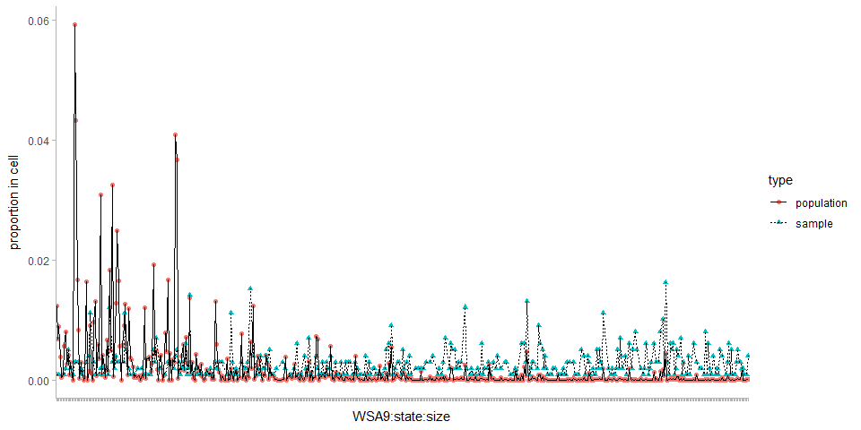

Another comparison between population and sample was constructed by ecoregion below. Lakes in the Coastal Plains (CPL) ecoregion, for example, were clearly undersampled relative to their proportion of the population.

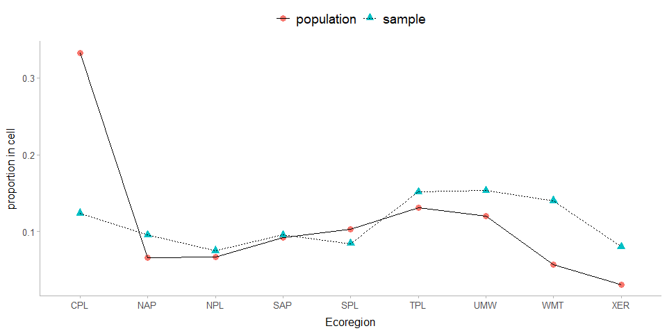

```r
pframe_eco <- pframe %>%
  group_by(WSA9) %>%
  summarise(n_lakes = sum(n_lakes)) %>%
  ungroup() %>%
  mutate(prop_cell = round(n_lakes/sum(n_lakes), 7)) %>%
  ungroup() %>%
  mutate(type = 'population')

samp_props_eco <- samp_props %>%
  group_by(WSA9) %>%
  summarise(n_lakes = sum(n_lakes)) %>%
  ungroup() %>%
  mutate(prop_cell = round(n_lakes/sum(n_lakes), 7)) %>%
  ungroup() %>%
  mutate(type = 'sample')

pframe_eco %>%
  bind_rows(samp_props_eco) %>%
  ggplot(mapping = aes(x = WSA9, y = prop_cell, group = type, linetype = type)) +
  geom_point(stat = "identity", aes( shape = type, color = type), size = 3) +
  geom_line() +
  theme_tidybayes() +
  xlab("Ecoregion") +
  ylab("proportion in cell") +
  theme(legend.position = "top",
        legend.title = element_blank(),
        legend.text = element_text(size = 14)) +
  theme(text = element_text(size = 12))
```

A similar comparison by state was constructed below.

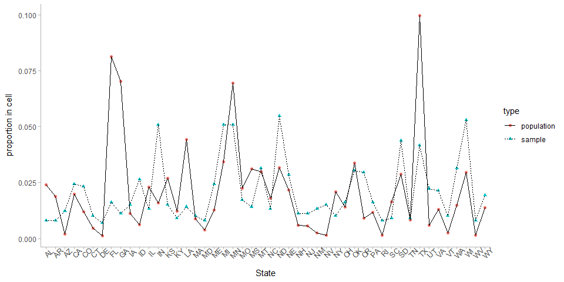

```r
pframe_state <- pframe %>%
  group_by(state) %>%
  summarise(n_lakes = sum(n_lakes)) %>%
  ungroup() %>%
  mutate(prop_cell = round(n_lakes/sum(n_lakes), 7)) %>%
  ungroup() %>%
  mutate(type = 'population')

samp_props_state <- samp_props %>%
  group_by(state) %>%
  summarise(n_lakes = sum(n_lakes)) %>%
  ungroup() %>%
  mutate(prop_cell = round(n_lakes/sum(n_lakes), 7)) %>%
  ungroup() %>%
  mutate(type = 'sample')

pframe_state %>%
  bind_rows(samp_props_state) %>%
  ggplot(mapping = aes(x = state, y = prop_cell, group = type, linetype = type)) +
  geom_point(stat = "identity", aes(shape = type, color = type)) +
  geom_line() +
  theme_tidybayes() +
  theme(axis.text.x = element_text(angle = 45)) +
  xlab("State") +
  ylab("proportion in cell")
```

Finally, a comparison by NLA size category is shown below. Waterbodies of the smallest size category were heavily under-sampled relative to the POI and those from the larger size categories were over-sampled.

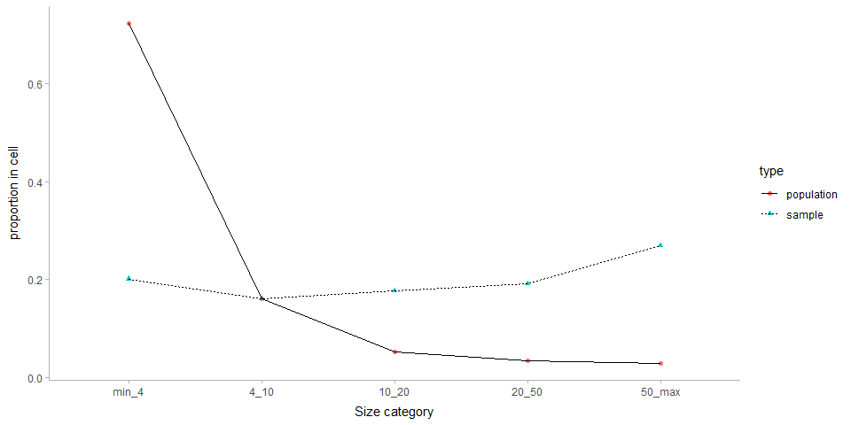

```r
pframe_size <- pframe %>%
  group_by(size_cat) %>%
  summarise(n_lakes = sum(n_lakes)) %>%
  ungroup() %>%
  mutate(prop_cell = round(n_lakes/sum(n_lakes), 7)) %>%
  ungroup() %>%
  mutate(type = 'population')

samp_props_size <- samp_props %>%
  group_by(size_cat) %>%
  summarise(n_lakes = sum(n_lakes)) %>%
  ungroup() %>%
  mutate(prop_cell = round(n_lakes/sum(n_lakes), 7)) %>%
  ungroup() %>%
  mutate(type = 'sample')

pframe_size %>%
  bind_rows(samp_props_size) %>%
  ggplot(mapping = aes(x = size_cat, y = prop_cell, group = type, linetype = type)) +
  geom_point(stat = "identity", aes( shape = type, color = type)) +
  geom_line() +
  theme_tidybayes() +
  xlab("Size category") +
  ylab("proportion in cell")
```

## 2.4 Sample-based estimates

Below are (naive) estimates, based only on the sample, for national means for dissolved and equilibrium N2O and the saturation ratio.

Dissolved N2O:

```r
df_model %>%
  summarise(mean = mean(n2o),
             sd = sd(n2o))
```

```
## # A tibble: 1 × 2
##    mean    sd
##   <dbl> <dbl>
## 1  8.72  9.52
```

Equilibrium N2O:

```r
df_model %>%
  summarise(mean = mean(n2o_eq),
             sd = sd(n2o_eq))
```

```
## # A tibble: 1 × 2
##    mean    sd
##   <dbl> <dbl>
## 1  7.48 0.845
```

Saturation ratio:

```r
df_model %>%
  summarise(mean = mean(n2o / n2o_eq),
             sd = sd(n2o / n2o_eq))
```

```
## # A tibble: 1 × 2
##    mean    sd
##   <dbl> <dbl>
## 1  1.17  1.30
```

Roughly 67% of lakes in the sample were under-saturated (i.e., saturation ratio < 1):

```r
df_model %>%
  summarise(prop_undersat = sum((n2o / n2o_eq) < 1) / 984)
```

```
## # A tibble: 1 × 1
##   prop_undersat
##           <dbl>
## 1         0.666
```

Using only the sample observations again, a plot was constructed of the overall mean (dashed line) along with the ecoregion-specific means (black circles). The shaded areas indicate +/- 1 standard deviation. Neither dissolved N2O nor the saturation ratio were clearly structured by ecoregion in the sample, but there did appear to be some potential structure along this variable in the equilibrium N2O observations.

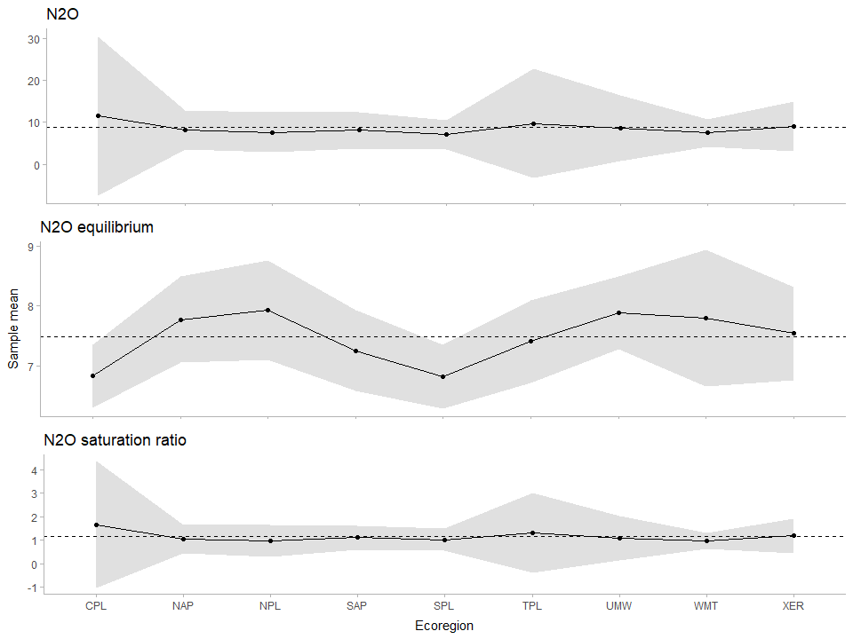

The same summary by state is below.

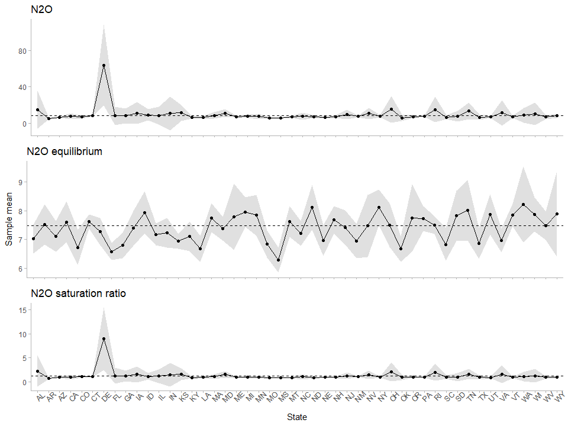

Finally, the same summary by size category.

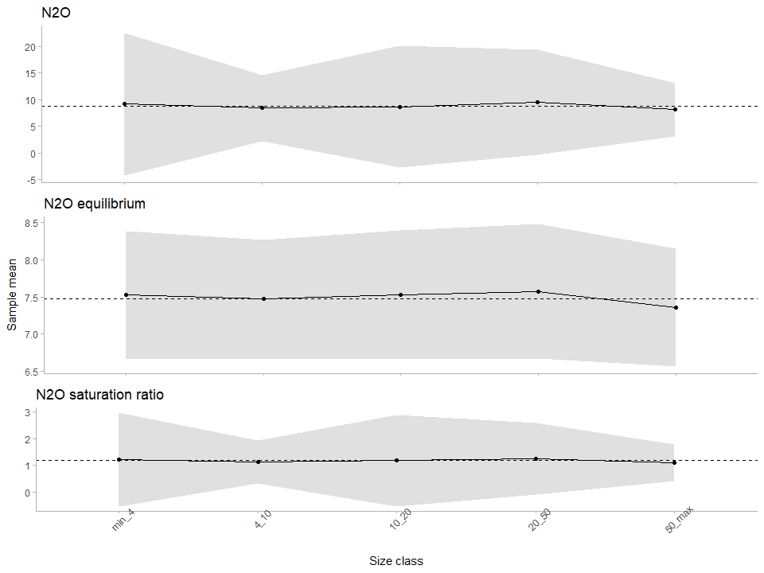

## 2.5 Sample data exploration

Below, the distribution N2O concentrations for the sample was summarized using a density and rug plot. Note the natural log scale of the x-axis. Both the dissolved and equilibrium N2O data had considerable right skew even after the log transformation. This was not unexpected and has been noted in other studies (*e.g.*, Webb et al. 2019). The saturation ratio was also skewed (sat_ratio = n2o / n2o_eq).

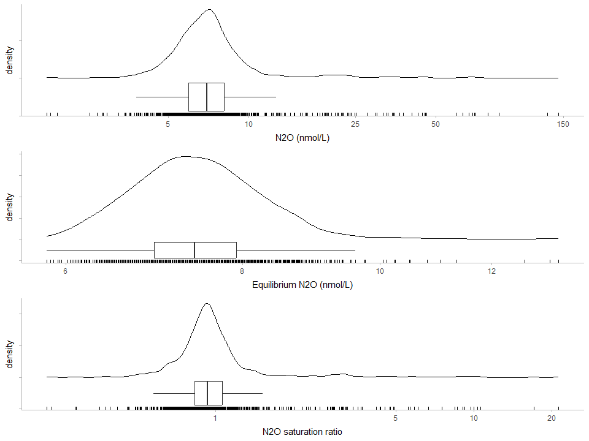

Below are plots of dissolved N2O vs. NO3 and some other potential covariates. This first plot shows log(N2O) vs. log(NO3), as well as the ordinal categories assigned to NO3 (vertical lines). The leftmost vertical line is dashed and separates the NO3 observations below the detection limit. The trend is increasing and nonlinear on the log scale, with increasing variance in N2O as NO3 increased.

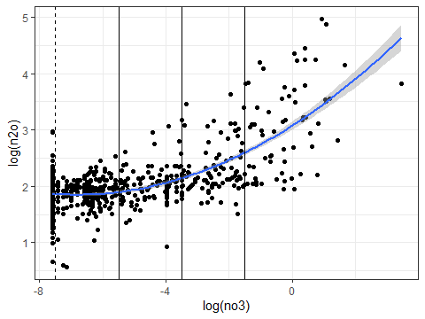

Below is a plot of N2O vs. the surface temperature observations.

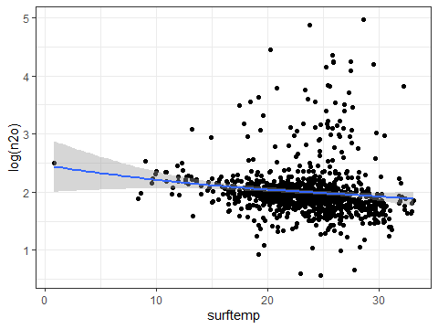

Below are plots of dissolved N2O vs. NO3 for 3 quantiles of the surface temperature measurements (quantiles increasing from 1 to 3). This plot suggested that the NO3 effect on N2O may have been stronger in lakes with higher observed temperatures.

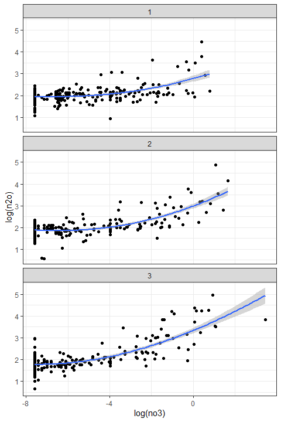

Below is a plot of N2O vs. the natural log of the surface area data for each lake from the NHD. The plot doesn’t suggest a strong effect, but the pattern of variation suggests more variability in dissolved N2O in smaller lakes.

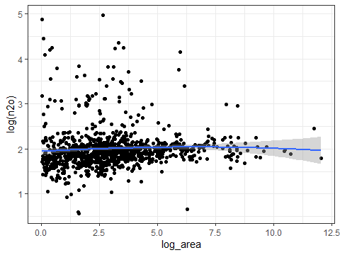

The next plot below shows the relationship between dissolved N2O and NO3 at 3 different quantiles (increasing 1 to 3) of the log-scaled lake surface area estimates. This plot perhaps suggests a weaker NO3 effect in the largest lakes.

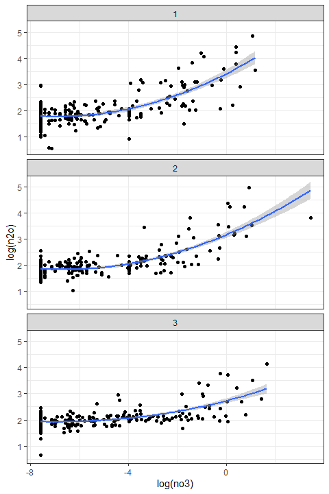

Below is a plot of N2O vs. the natural log of the dissolved oxygen measurements. Measurements for DO were missing from 4 samples and these observations were excluded from the plot below. The plot suggests a positive effect of DO, but the pattern may be dominated by extreme values at the upper and lower end of log(DO).

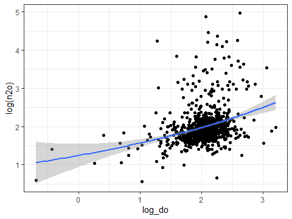

The next plot below shows the relationship between dissolved N2O and NO3 at 3 different quantiles (increasing 1 to 3) of the log-scaled dissolved oxygen measurements. Measurements for DO were missing from 4 samples and these observations were excluded from the plot below. This plot doesn’t suggest a clear interaction of DO with NO3.

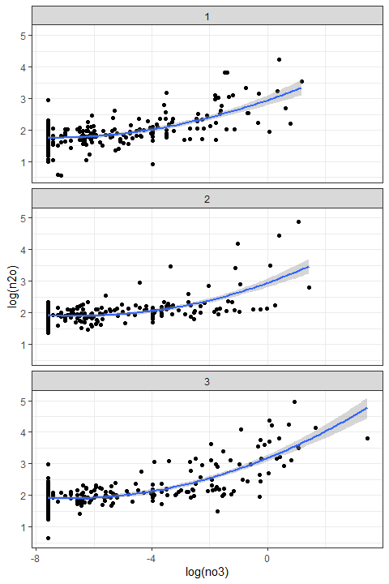

Below is a plot of N2O vs. the natural log of the chlorophyll a measurements. Measurements were missing from 4 samples and these observations were excluded from the plot. The plot suggests perhaps a slight negative effect of chl-a.

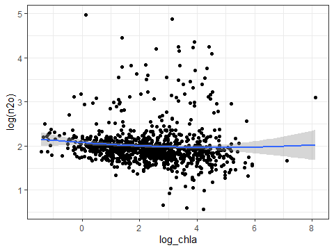

The next plot below shows the relationship between dissolved N2O and NO3 at 3 different quantiles (increasing 1 to 3) of the log-scaled chlorophyll a measurements. Measurements for chl-a were missing from 4 samples and these observations were excluded from the plot below. There is no clear interaction indicated in the plot below, but the NO3 effect may be stronger at high chl-a levels.

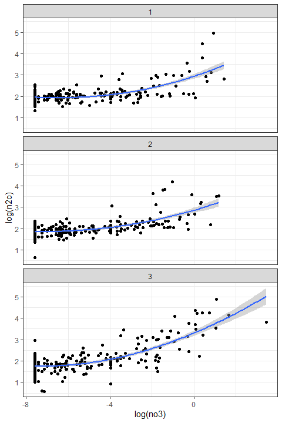

Below is a plot of N2O vs. a square root transformation of the bouyancy factor (BF) metric. Again, measurements were missing from 4 samples and these observations were excluded from the plot. The plot suggests perhaps a slight negative effect of the BF metric.

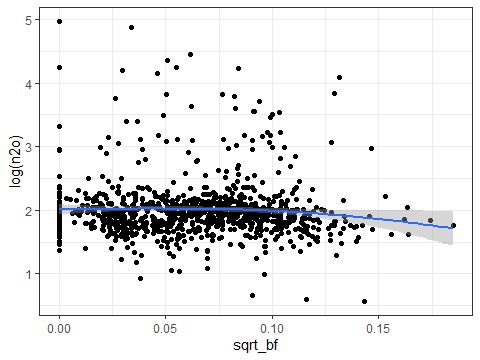

The next plot below shows the relationship between dissolved N2O and NO3 at 3 different quantiles (increasing 1 to 3) of the BF metric. There is no clear interaction indicated in the plot below.

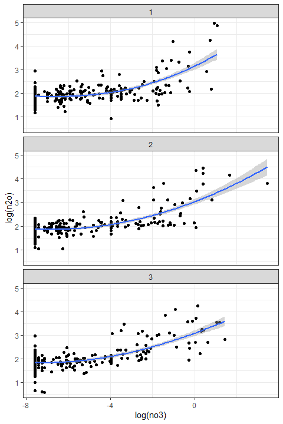

Similar plots are below, but with NO3 expressed as an ordered categorical variable with 5 levels. The positive and monotonic trends area similar to the previous plots where NO3 was treated as continuous. Note the large number of observations in the first NO3 category (no3_cat = 1). This category represented all of the observations for NO3 that were below the detection limit, which was most of the data.

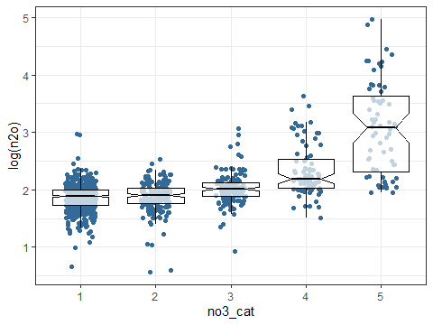

The plot below is N2O vs NO3 for three quantiles (increasing) of surface temperature.

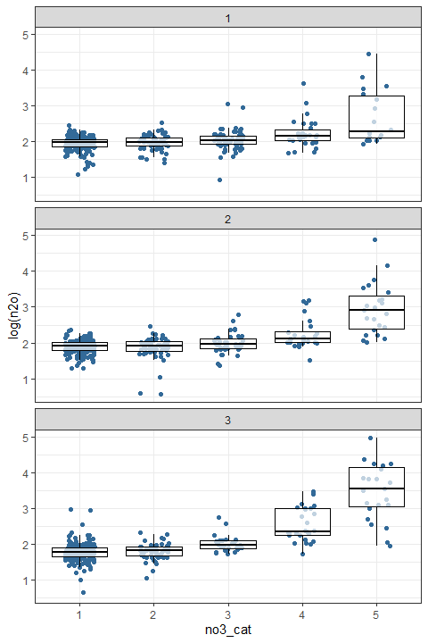

The plot below is N2O vs NO3 for three quantiles (increasing) of (log) surface area.

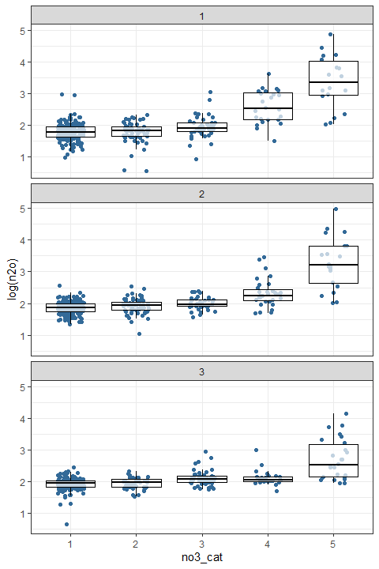

Below is a plot of log(dissolved N2O) vs. log(NO3) by ecoregion, which suggested that the NO3 effect on dissolved N2O may have varied by ecoregion.

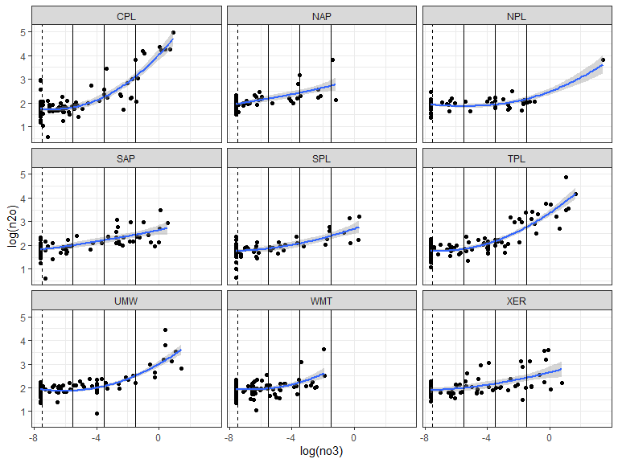

Below is the same plot as above but for the ordered categorical version of NO3.

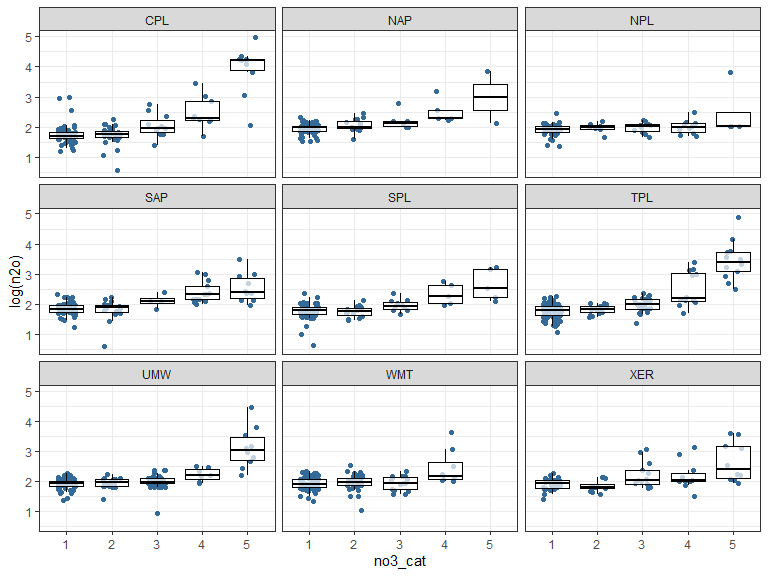

A plot below shows the relationships between dissolved N2O and log(NO3) by state, but within just the Temperate Plains (TPL) ecoregion. Within states, the number of observations were relatively small, but the trends were perhaps more linear.

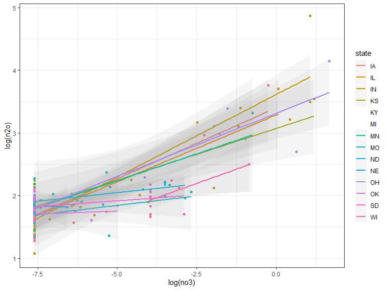

# 3 Model Fitting

## 3.1 Model 1

The first model for the two N2O responses, conditioned only on the study design factors.

```r
bf_n2o <- bf(log(n2o) ~ 1 +
               (1 | a | WSA9) +
               (1 | b | WSA9:state) +
               (1 | c | WSA9:state:size_cat),
             family = gaussian())

bf_n2oeq <- bf(log(n2o_eq) ~ 1 +
               (1 | a | WSA9) +
               (1 | b | WSA9:state) +
               (1 | c | WSA9:state:size_cat),
             family = gaussian())

priors <- c(
  prior(normal(2, 1), class = "Intercept", resp = "logn2o"), # centered near data mean
  prior(exponential(2), class = "sd", resp = "logn2o"),
  prior(exponential(2), class = "sigma", resp = "logn2o"),
  prior(normal(2, 1), class = "Intercept", resp = "logn2oeq"), # centered near data mean
  prior(exponential(2), class = "sd", resp = "logn2oeq"),
  prior(exponential(2), class = "sigma", resp = "logn2oeq"),
  prior(lkj(2), class = "rescor"),
  prior(lkj(2), class = "cor")
  )

n2o_mod1 <- brm(bf_n2o + bf_n2oeq + set_rescor(rescor = TRUE),
                data = df_model,
                prior = priors,
                control = list(adapt_delta = 0.99, max_treedepth = 14),
                #sample_prior = "only",
                save_pars = save_pars(all = TRUE),
                seed = 145,
                chains=4,
                iter=5000,
                cores=4)

save(n2o_mod1, file = "C:/Users/rmartin/OneDrive - Environmental Protection Agency (EPA)/Documents/AE_Reservoirs/DissolvedGasNla/modelFiles/n2o_mod1.rda")
```

### 3.1.1 Summarize fit

```
##  Family: MV(gaussian, gaussian)
##   Links: mu = identity; sigma = identity
##          mu = identity; sigma = identity
## Formula: log(n2o) ~ 1 + (1 | a | WSA9) + (1 | b | WSA9:state) + (1 | c | WSA9:state:size_cat)
##          log(n2o_eq) ~ 1 + (1 | a | WSA9) + (1 | b | WSA9:state) + (1 | c | WSA9:state:size_cat)
##    Data: df_model (Number of observations: 984)
##   Draws: 4 chains, each with iter = 5000; warmup = 2500; thin = 1;
##          total post-warmup draws = 10000
##
## Priors:
## Intercept_logn2o ~ normal(2, 1)
## Intercept_logn2oeq ~ normal(2, 1)
## L ~ lkj_corr_cholesky(2)
## Lrescor ~ lkj_corr_cholesky(2)
## <lower=0> sd_logn2o ~ exponential(2)
## <lower=0> sd_logn2oeq ~ exponential(2)
## <lower=0> sigma_logn2o ~ exponential(2)
## <lower=0> sigma_logn2oeq ~ exponential(2)
##
## Multilevel Hyperparameters:
## ~WSA9 (Number of levels: 9)
##                                          Estimate Est.Error l-95% CI u-95% CI
## sd(logn2o_Intercept)                         0.04      0.03     0.00     0.13
## sd(logn2oeq_Intercept)                       0.06      0.02     0.03     0.11
## cor(logn2o_Intercept,logn2oeq_Intercept)     0.05      0.44    -0.80     0.83
##                                          Rhat Bulk_ESS Tail_ESS
## sd(logn2o_Intercept)                     1.00     2475     4230
## sd(logn2oeq_Intercept)                   1.00     3326     5332
## cor(logn2o_Intercept,logn2oeq_Intercept) 1.01     1141     3129
##
## ~WSA9:state (Number of levels: 96)
##                                          Estimate Est.Error l-95% CI u-95% CI
## sd(logn2o_Intercept)                         0.26      0.03     0.21     0.32
## sd(logn2oeq_Intercept)                       0.04      0.01     0.03     0.05
## cor(logn2o_Intercept,logn2oeq_Intercept)     0.24      0.15    -0.07     0.52
##                                          Rhat Bulk_ESS Tail_ESS
## sd(logn2o_Intercept)                     1.00     3199     4775
## sd(logn2oeq_Intercept)                   1.00     3549     5476
## cor(logn2o_Intercept,logn2oeq_Intercept) 1.00     3332     5553
##
```

[output cut: 14 more lines]

```
##
## Further Distributional Parameters:
##                Estimate Est.Error l-95% CI u-95% CI Rhat Bulk_ESS Tail_ESS
## sigma_logn2o       0.40      0.01     0.37     0.42 1.00     2749     5523
## sigma_logn2oeq     0.08      0.00     0.08     0.09 1.00     4790     6698
##
## Residual Correlations:
##                         Estimate Est.Error l-95% CI u-95% CI Rhat Bulk_ESS
## rescor(logn2o,logn2oeq)     0.21      0.04     0.14     0.27 1.00     6172
##                         Tail_ESS
## rescor(logn2o,logn2oeq)     7243
##
## Draws were sampled using sampling(NUTS). For each parameter, Bulk_ESS
## and Tail_ESS are effective sample size measures, and Rhat is the potential
## scale reduction factor on split chains (at convergence, Rhat = 1).
```

In the summary above, the estimated standard deviations for the varying group effects on the mean behavior of the dissolved N2O response suggested fairly low, but non-zero variability across each of the three levels. The standard deviations estimated for the same varying effects for equilibrium N2O were also relatively small. Finally, note the relatively small, but positive residual correlation between the two N2O responses.

Before investing too much into inferences from this model, however, the model fit was evaluated below using a series of graphical posterior predictive checks (PPC, Gelman et al. 2014; Gelman, Hill, and Vehtari 2020, Ch. 11).

### 3.1.2 Model checks

#### 3.1.2.1 Dissolved N2O

Below are a series of panels illustrating graphical PPCs for the dissolved N2O component of the multivariate model. The top left panel compares a density plot of the observed data (black line) to density estimates drawn for 200 samples from the posterior predictive distribution (PPD; blue lines) of the fitted model. The top right panel compares the cumulative density distributions in the same manner. The left middle panel compares means *vs.* standard deviations for 1000 draws from the PPD (blue dots) to the sample mean *vs.* standard deviation (black dot). The right middle panel compares skewness *vs.* kurtosis for 1000 draws from the PPD to the skewness *vs.* kurtosis estimates for the observed data. The bottom left panel compares max *vs.* min values for 1000 draws from the PPD to the max *vs.* min values of the sample data. Finally, the bottom right panel shows the observed *vs.* average predicted values for each observation in the sample. The average predicted values were calculated as the mean prediction for each observation in the PPD based on 1000 draws.

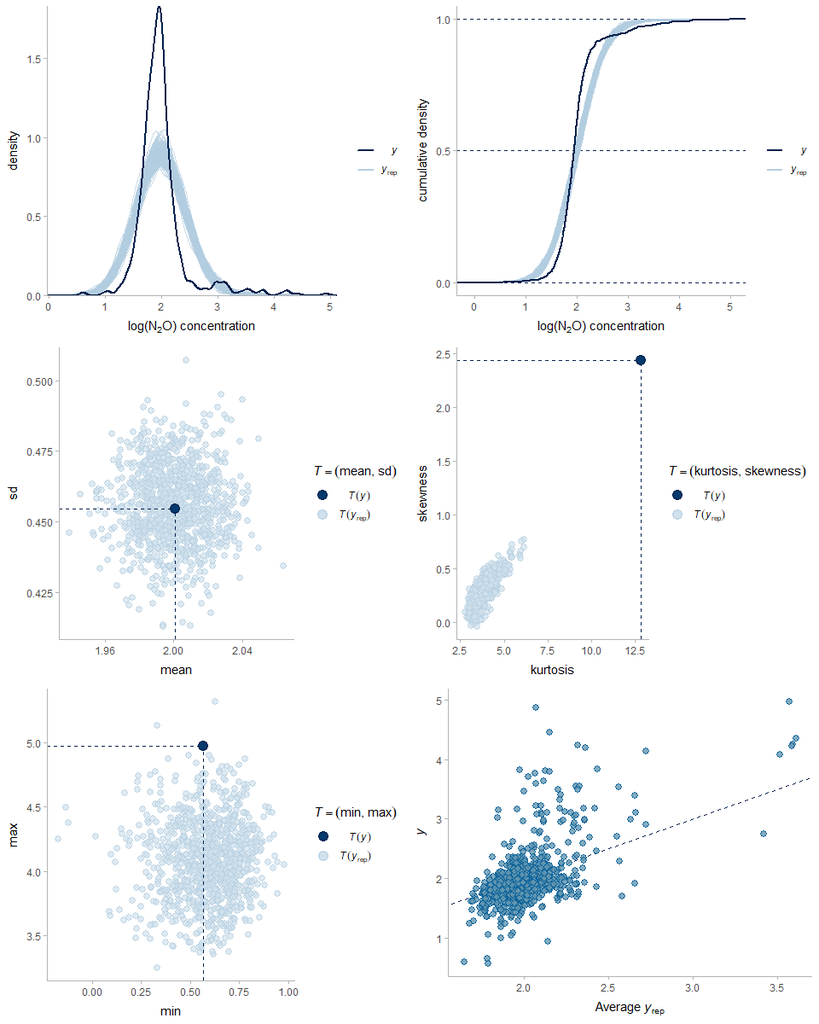

The general takeaway from the PPCs above was that the model replicated the central tendency of the observed data fairly well, but failed to sufficiently replicate other important aspects of the distribution, such as skewness and kurtosis. The observed *vs.* average predictions scatterplot also suggested substantial heteroscedasticity in the errors.

The same checks were run below, but for the test set of 95 held-out, second-visit data points. The patterns in misfit were similar to the patterns indicated in the PPCs with the training data above.

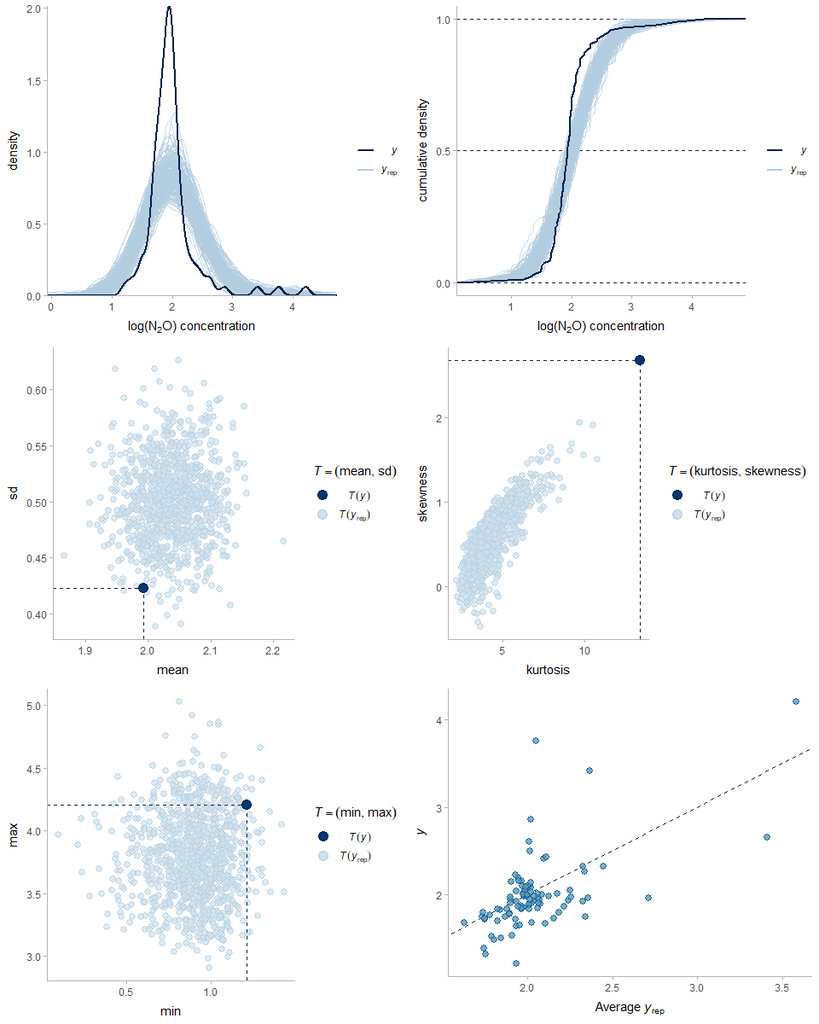

#### 3.1.2.2 Equilibrium N2O

Below are PPCs for the equilibrium N2O component of the model. As with the dissolved N2O PPCs, the model seemed to do an OK job at replicating the central tendency, but performed less well at replicating other important aspects of the overall distribution.

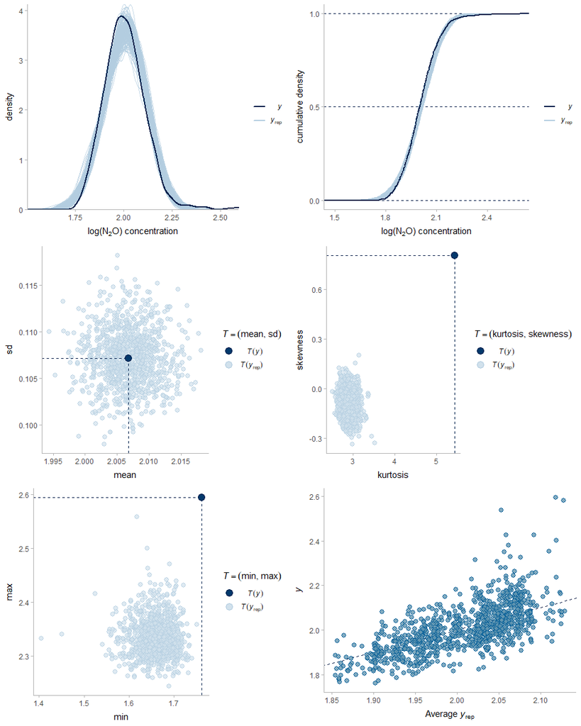

Below are the same PPCs for equilibrium N2O in the re-visit sites.

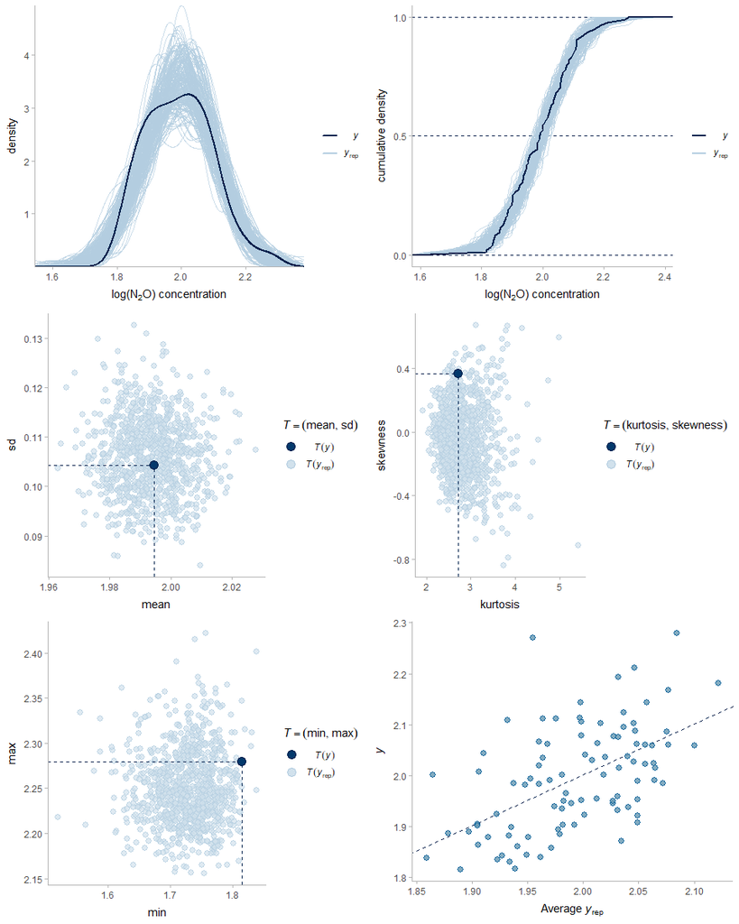